#7TotaldescriptivaClean5.Rmd #install.packages(“rmarkdown”) #library(“rmarkdown”)

READING CREDSCO.CSV. NOTE: Change the path of the file for the proper one in your computer.

Remember that subfolders must be indicated by “/” and not by “"

WARNING: data must have been properly declared before (factors, dates…)

```r
# dd <- read.table("D:/karina/docencia/areferenciesPPT/0DadesPractiques/CREDSCO/credscoCategoriques2.csv",header=T, sep=";", dec=",")
#dd<- read.csv("D:/karina/TFGs/GrauEstadistica/MarcPinar/data.csv", sep=";")

#dataset<-"platjaDaro"
#dataset<-"futbol"

#setwd("D:/karina/projectes/ON/a2020INSESSCOVIDisocial/18DadesTallers")
#dd<- read.table("2Formulari5TPlataDarov1.csv",header=T, sep=",", dec=".", na.strings="*");
#dataset<-"planta"


dataset<-"Filtered_dataset"
```

Set the folder where the word file is going to be generated ToDo: This should be a relative path

```r
#setwd("./Documents/UNI/MD/MD2526/")
#setwd(dirname(rstudioapi::getActiveDocumentContext()$path))
dd <- read.table("Filtered_dataset.csv", header=T, sep=",");
```

Check the type of the R object created for the dataset

```r
class(dd)
```

```
## [1] "data.frame"
```

without including the R instruction in the final document

```
## [1] "data.frame"
```

Get dimensions of the dataset

```r
dim(dd)
```

```
## [1] 1700   16
```

```r
n<-dim(dd)[1]
K<-dim(dd)[2]

n
```

```
## [1] 1700
```

```r
K
```

```
## [1] 16
```

Check the variables

```r
names(dd)
```

```
##  [1] "AGE"        "SEX"        "INF_ANAM"   "STENOK_AN"  "GB"
##  [6] "SIM_GIPERT" "ZSN_A"      "endocr_01"  "S_AD_ORIT"  "D_AD_ORIT"
## [11] "K_BLOOD"    "NA_BLOOD"   "L_BLOOD"    "ROE"        "COM_SUM"
## [16] "LET_IS"
```

```r
data.frame(ID = seq_along(dd), Name = names(dd))
```

| ID | Name |
| --- | --- |
| 1 | AGE |
| 2 | SEX |
| 3 | INF_ANAM |
| 4 | STENOK_AN |
| 5 | GB |
| 6 | SIM_GIPERT |
| 7 | ZSN_A |
| 8 | endocr_01 |
| 9 | S_AD_ORIT |
| 10 | D_AD_ORIT |

[output cut: 6 more lines]

Decide if you need to declare some more factor or date

```r
descriptiva<-function(X, nom){
  if (!(is.numeric(X))){
    # Categoricas

    frecs<-table(as.factor(X), useNA="ifany")
    proportions<-frecs/n
    #ojo, decidir si calcular porcentages con o sin missing values
    pie(frecs, cex=0.6, main=paste("Pie of", nom))

    # 1. Guarda la configuración original de los parámetros gráficos
    old_par <- par(no.readonly = TRUE)

    # 2. Establece los nuevos márgenes (ej: 10 líneas para el margen inferior)
    par(mar = c(10, 4, 4, 2))


    barplot(frecs, las=3, cex.names=0.7, main=paste("Barplot of", nom), col=listOfColors)


    par(old_par)

    print(paste("Number of modalities: ", length(frecs)))
    print("Frequency table")
    print(frecs)
    print("Relative frequency table (proportions)")
    print(proportions)
    print("Frequency table sorted")
    print(sort(frecs, decreasing=TRUE))
    print("Relative frequency table (proportions) sorted")
    print(sort(proportions, decreasing=TRUE))

   }
  else{
       # Numericas

       hist(X, main=paste("Histogram of", nom))
       boxplot(X, horizontal=TRUE, main=paste("Boxplot of",nom))
       print("Extended Summary Statistics")
       print(summary(X))
       print(paste("sd: ", sd(X, na.rm=TRUE)))
       print(paste("vc: ", sd(X, na.rm=TRUE)/mean(X, na.rm=TRUE)))
       print("Q-Q plot ")
      qqnorm(X, main = paste("QQ Plot of", nom)) # Crea el gráfico Q-Q
      qqline(X, col="red") # Añade la línea de referencia normal

      shapiro<- shapiro.test(X)
      print(shapiro)
  }

}

factor_with_na <- function(x, levels, labels, ordered = FALSE) {
  f <- factor(x, levels = levels, labels = labels, ordered = ordered)
  f <- addNA(f)   # convierte los NA en un nivel extra
  levels(f)[is.na(levels(f))] <- "NA"
  return(f)
}

#dataset<-dd
actives<-c(1:K)
#colDate<-1
#if (dataset=="platjaDaro")
#  {dd[,colDate]<-as.Date(dd[, colDate], format="%d/%m/%y %h:%m:%s")
#   actives<-c(3:44)
#   }
```

Basic descriptive analysis for numerical variables

(decide the maximum number of colors you can need in a graph based on your metadata file)

```
## [1] "variable  2 : SEX"
```

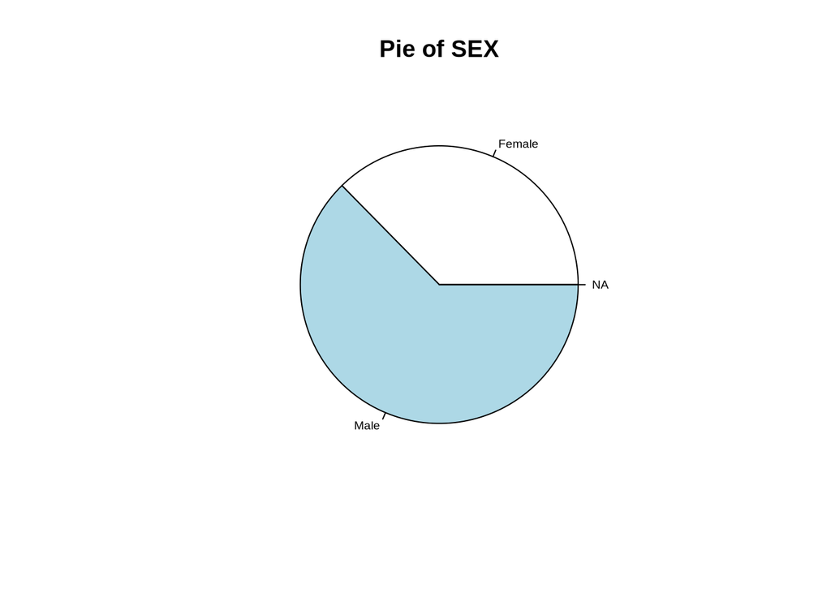

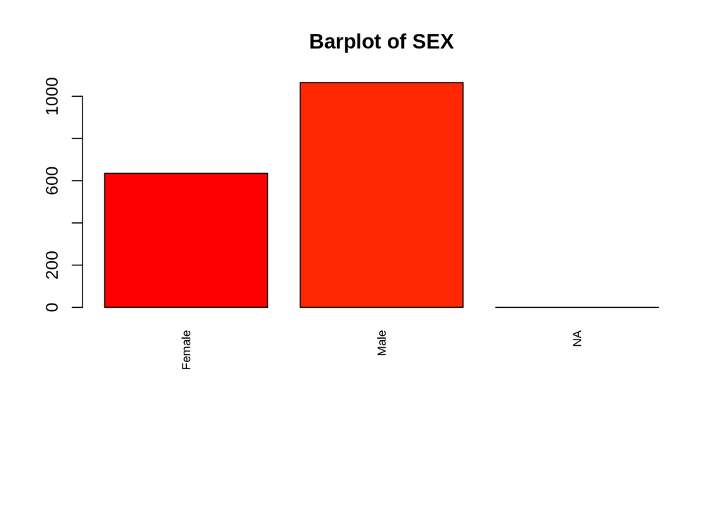

```
## [1] "Number of modalities:  3"
## [1] "Frequency table"
##
## Female   Male     NA
##    635   1065      0
## [1] "Relative frequency table (proportions)"
##
##    Female      Male        NA
## 0.3735294 0.6264706 0.0000000
## [1] "Frequency table sorted"
##
##   Male Female     NA
##   1065    635      0
## [1] "Relative frequency table (proportions) sorted"
##
##      Male    Female        NA
## 0.6264706 0.3735294 0.0000000
## [1] "variable  3 : INF_ANAM"
```

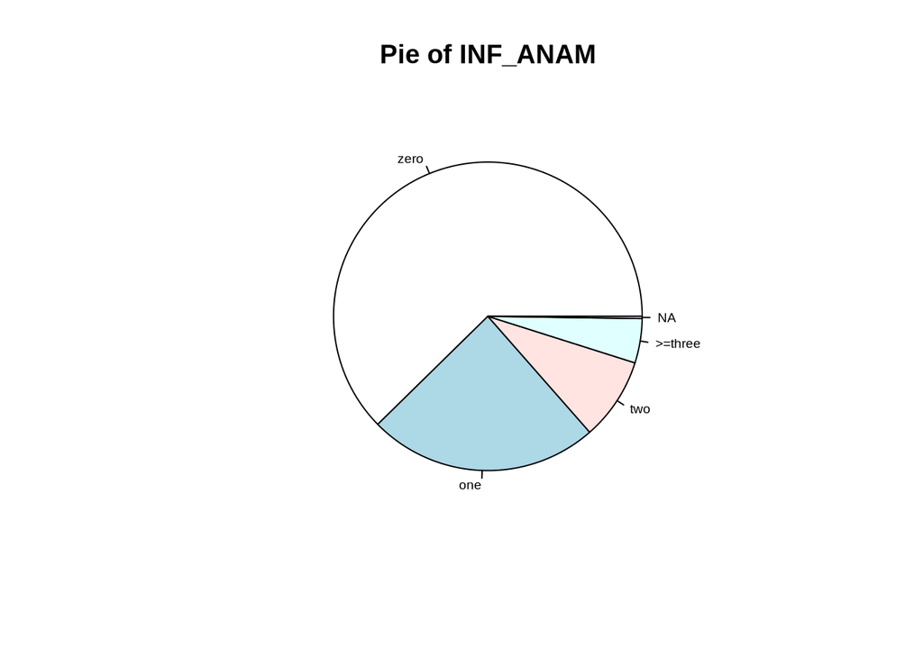

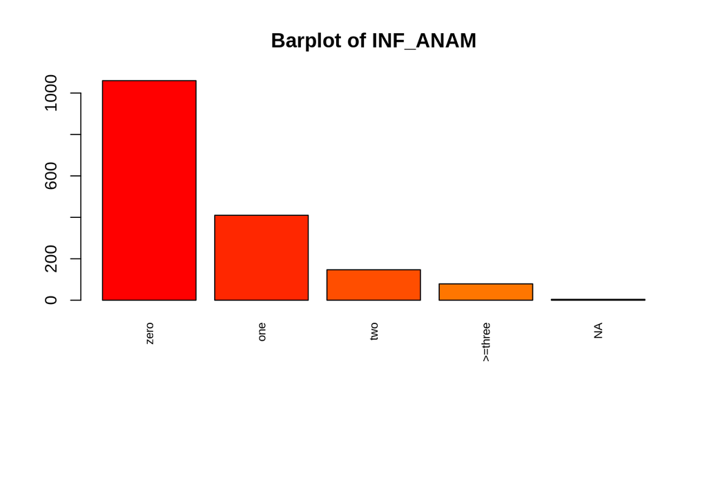

```
## [1] "Number of modalities:  5"
## [1] "Frequency table"
##
##    zero     one     two >=three      NA
##    1060     410     147      79       4
## [1] "Relative frequency table (proportions)"
##
##        zero         one         two     >=three          NA
## 0.623529412 0.241176471 0.086470588 0.046470588 0.002352941
## [1] "Frequency table sorted"
##
##    zero     one     two >=three      NA
##    1060     410     147      79       4
## [1] "Relative frequency table (proportions) sorted"
##
##        zero         one         two     >=three          NA
## 0.623529412 0.241176471 0.086470588 0.046470588 0.002352941
## [1] "variable  4 : STENOK_AN"
```

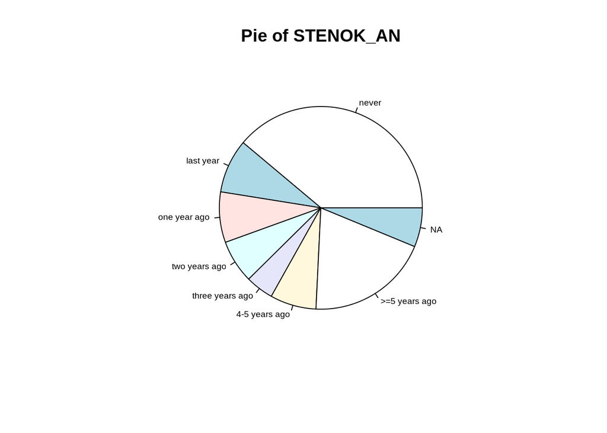

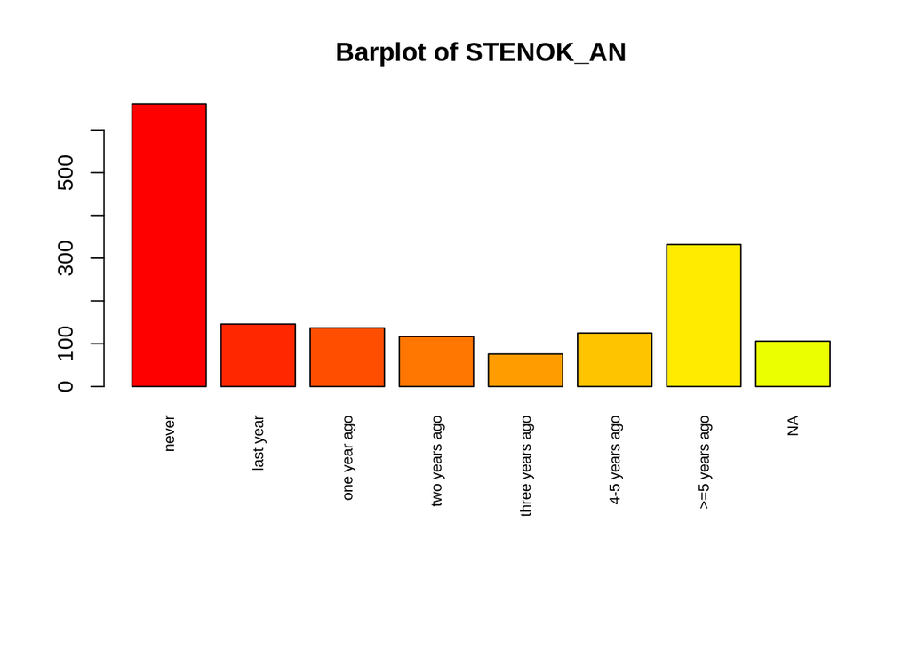

```
## [1] "Number of modalities:  8"
## [1] "Frequency table"
##
##           never       last year    one year ago   two years ago three years ago
##             661             146             137             117              76
##   4-5 years ago   >=5 years ago              NA
##             125             332             106
## [1] "Relative frequency table (proportions)"
##
##           never       last year    one year ago   two years ago three years ago
##      0.38882353      0.08588235      0.08058824      0.06882353      0.04470588
##   4-5 years ago   >=5 years ago              NA
##      0.07352941      0.19529412      0.06235294
## [1] "Frequency table sorted"
##
##           never   >=5 years ago       last year    one year ago   4-5 years ago
##             661             332             146             137             125
##   two years ago              NA three years ago
##             117             106              76
## [1] "Relative frequency table (proportions) sorted"
##
##           never   >=5 years ago       last year    one year ago   4-5 years ago
##      0.38882353      0.19529412      0.08588235      0.08058824      0.07352941
##   two years ago              NA three years ago
##      0.06882353      0.06235294      0.04470588
## [1] "variable  5 : GB"
```

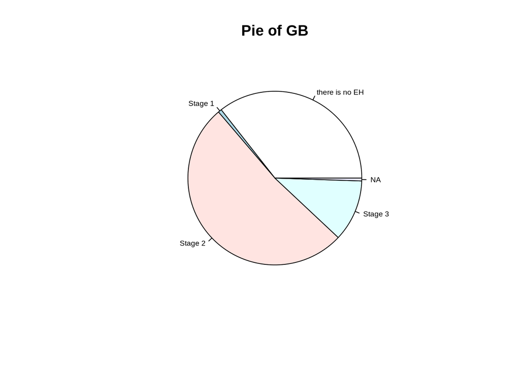

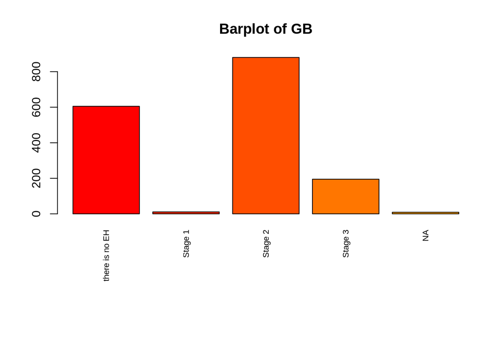

```
## [1] "Number of modalities:  5"
## [1] "Frequency table"
##
## there is no EH        Stage 1        Stage 2        Stage 3             NA
##            605             11            880            195              9
## [1] "Relative frequency table (proportions)"
##
## there is no EH        Stage 1        Stage 2        Stage 3             NA
##    0.355882353    0.006470588    0.517647059    0.114705882    0.005294118
## [1] "Frequency table sorted"
##
##        Stage 2 there is no EH        Stage 3        Stage 1             NA
##            880            605            195             11              9
## [1] "Relative frequency table (proportions) sorted"
##
##        Stage 2 there is no EH        Stage 3        Stage 1             NA
##    0.517647059    0.355882353    0.114705882    0.006470588    0.005294118
## [1] "variable  6 : SIM_GIPERT"
```

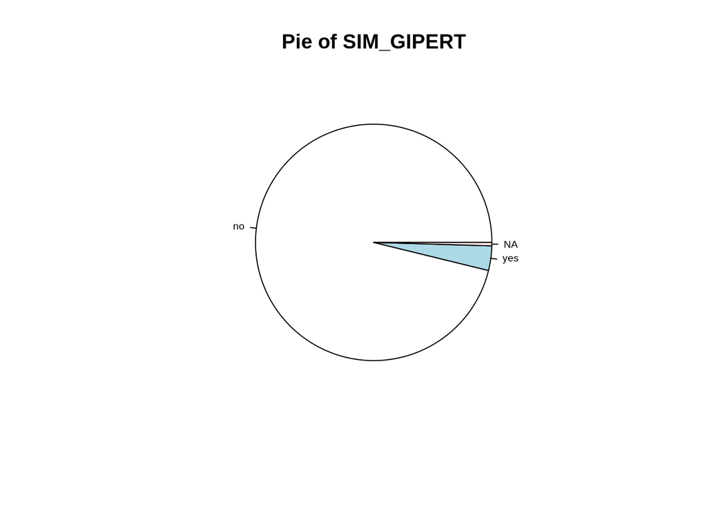

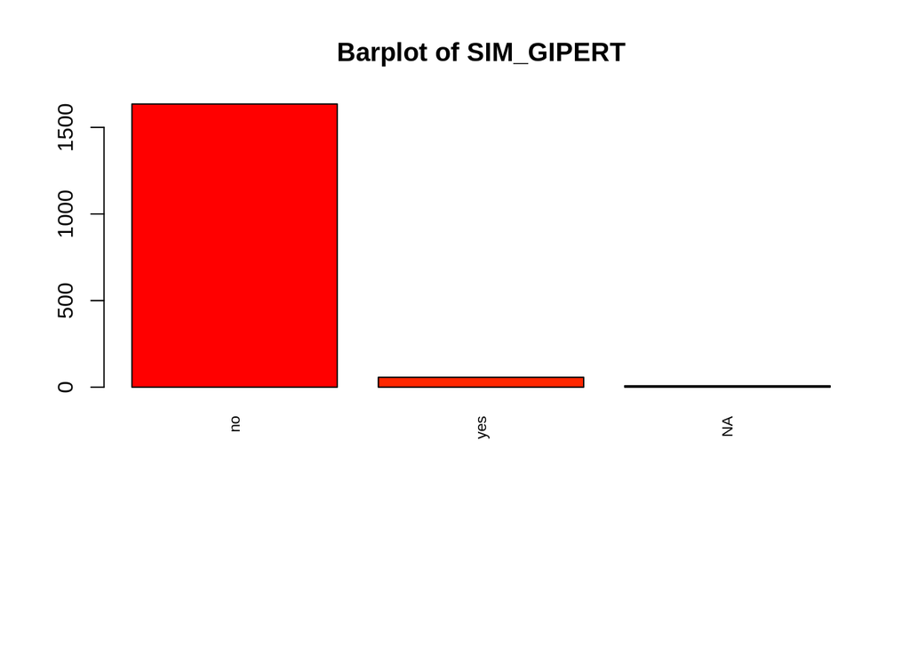

```
## [1] "Number of modalities:  3"
## [1] "Frequency table"
##
##   no  yes   NA
## 1635   57    8
## [1] "Relative frequency table (proportions)"
##
##          no         yes          NA
## 0.961764706 0.033529412 0.004705882
## [1] "Frequency table sorted"
##
##   no  yes   NA
## 1635   57    8
## [1] "Relative frequency table (proportions) sorted"
##
##          no         yes          NA
## 0.961764706 0.033529412 0.004705882
## [1] "variable  7 : ZSN_A"
```

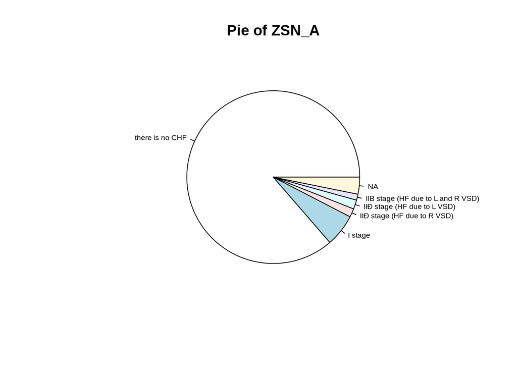

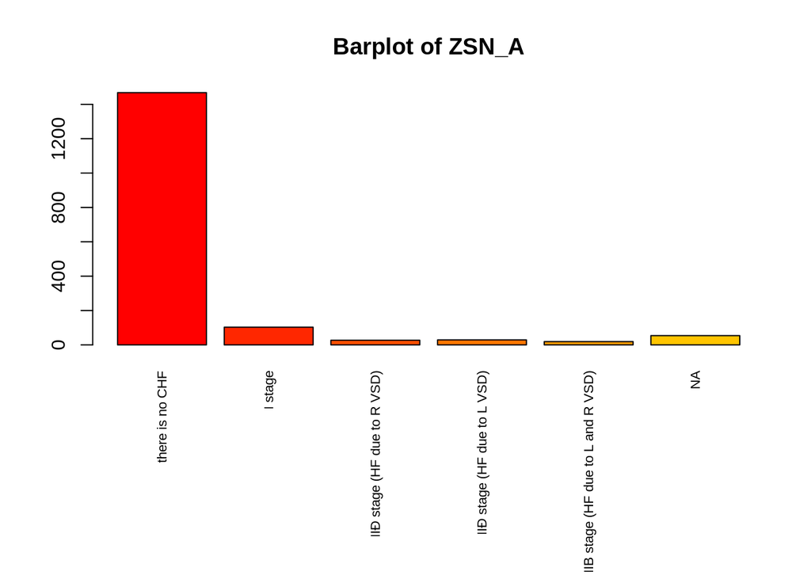

```
## [1] "Number of modalities:  6"
## [1] "Frequency table"
##
##                   there is no CHF                           I stage
##                              1468                               103
##       IIÐ stage (HF due to R VSD)       IIÐ stage (HF due to L VSD)
##                                27                                29
## IIB stage (HF due to L and R VSD)                                NA
##                                19                                54
## [1] "Relative frequency table (proportions)"
##
##                   there is no CHF                           I stage
##                        0.86352941                        0.06058824
##       IIÐ stage (HF due to R VSD)       IIÐ stage (HF due to L VSD)
##                        0.01588235                        0.01705882
## IIB stage (HF due to L and R VSD)                                NA
##                        0.01117647                        0.03176471
## [1] "Frequency table sorted"
##
##                   there is no CHF                           I stage
##                              1468                               103
##                                NA       IIÐ stage (HF due to L VSD)
##                                54                                29
##       IIÐ stage (HF due to R VSD) IIB stage (HF due to L and R VSD)
##                                27                                19
## [1] "Relative frequency table (proportions) sorted"
##
##                   there is no CHF                           I stage
##                        0.86352941                        0.06058824
##                                NA       IIÐ stage (HF due to L VSD)
##                        0.03176471                        0.01705882
##       IIÐ stage (HF due to R VSD) IIB stage (HF due to L and R VSD)
##                        0.01588235                        0.01117647
## [1] "variable  8 : endocr_01"
```

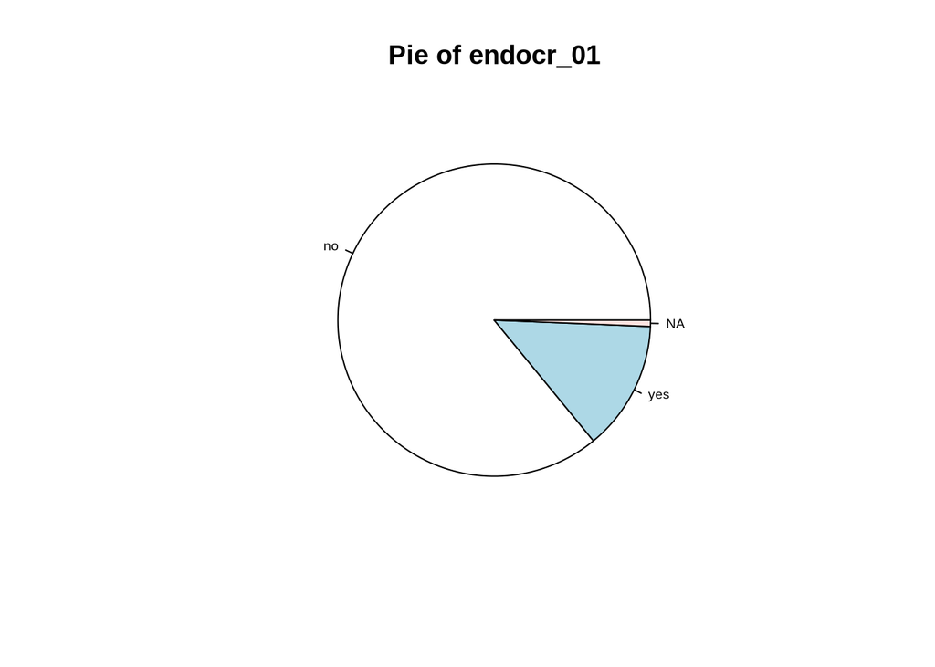

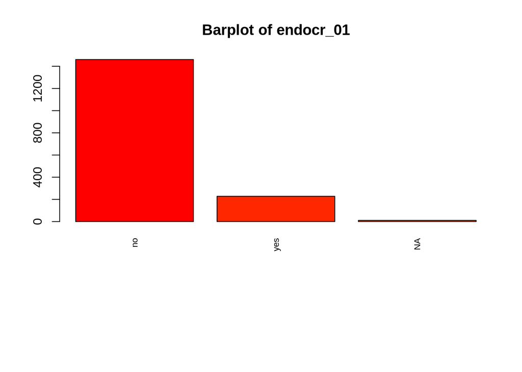

```
## [1] "Number of modalities:  3"
## [1] "Frequency table"
##
##   no  yes   NA
## 1461  228   11
## [1] "Relative frequency table (proportions)"
##
##          no         yes          NA
## 0.859411765 0.134117647 0.006470588
## [1] "Frequency table sorted"
##
##   no  yes   NA
## 1461  228   11
## [1] "Relative frequency table (proportions) sorted"
##
##          no         yes          NA
## 0.859411765 0.134117647 0.006470588
## [1] "variable  9 : S_AD_ORIT"
```

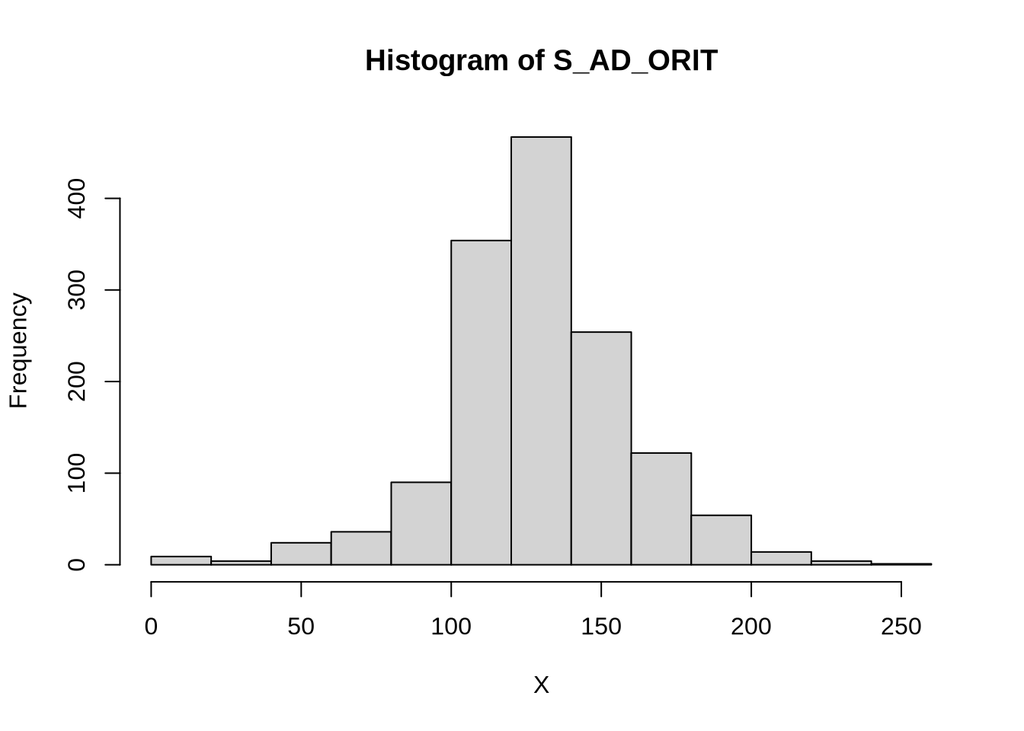

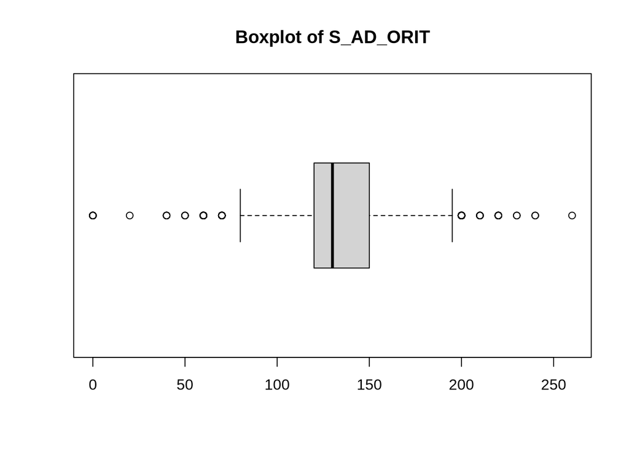

```
## [1] "Extended Summary Statistics"
##    Min. 1st Qu.  Median    Mean 3rd Qu.    Max.    NA's
##     0.0   120.0   130.0   134.6   150.0   260.0     267
## [1] "sd:  31.34838794429"
## [1] "vc:  0.232920643580575"
## [1] "Q-Q plot "
```

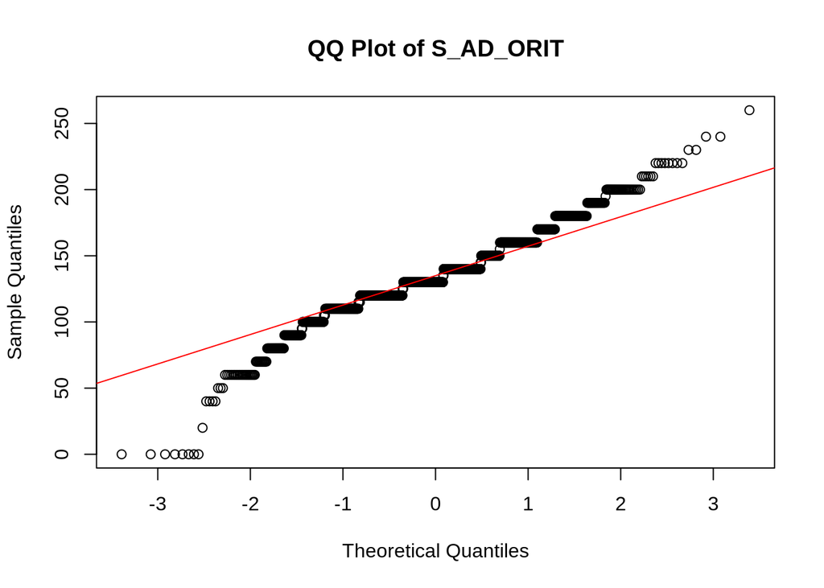

```
##
##  Shapiro-Wilk normality test
##
## data:  X
## W = 0.96085, p-value < 2.2e-16
##
## [1] "variable  10 : D_AD_ORIT"
```

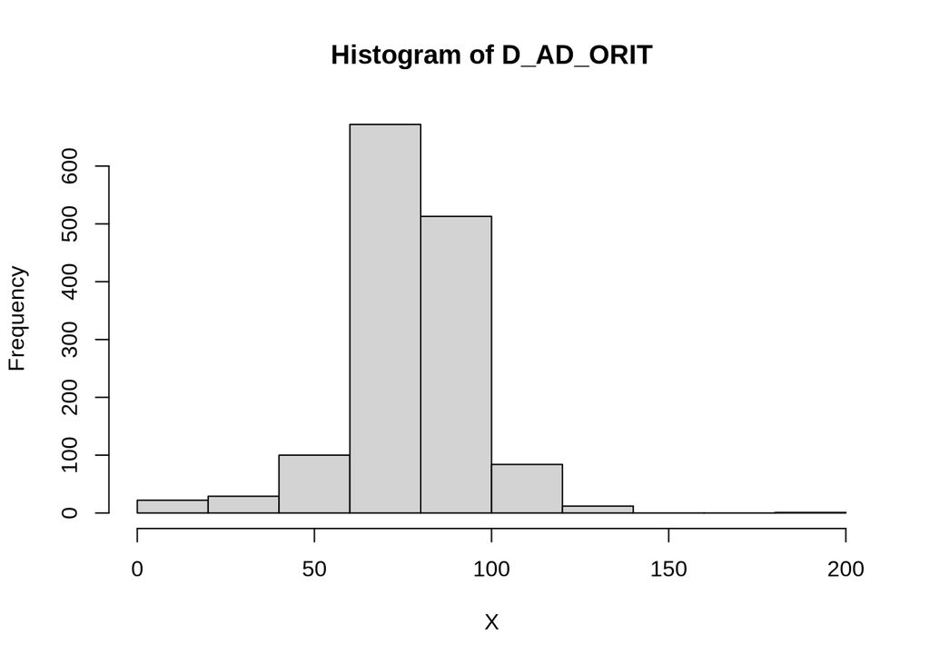

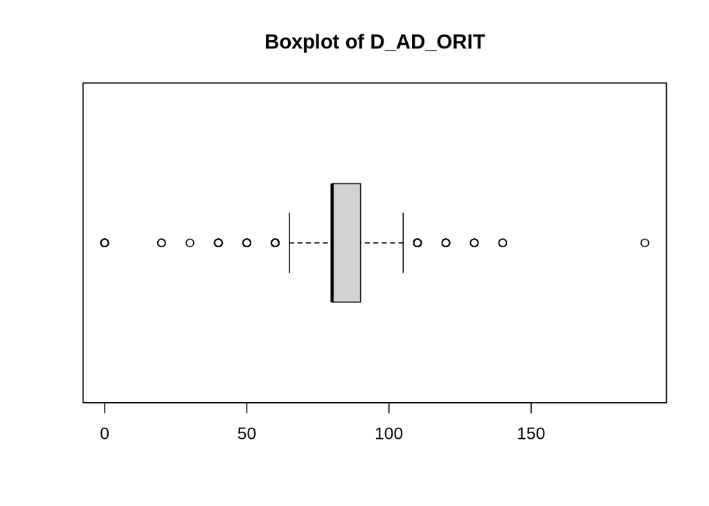

```
## [1] "Extended Summary Statistics"
##    Min. 1st Qu.  Median    Mean 3rd Qu.    Max.    NA's
##    0.00   80.00   80.00   82.75   90.00  190.00     267
## [1] "sd:  18.321063184769"
## [1] "vc:  0.221403976587738"
## [1] "Q-Q plot "
```

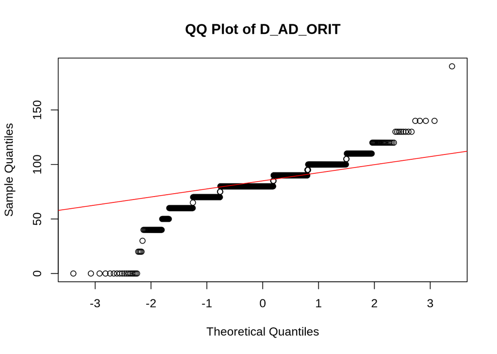

```
##
##  Shapiro-Wilk normality test
##
## data:  X
## W = 0.87857, p-value < 2.2e-16
##
## [1] "variable  11 : K_BLOOD"
```

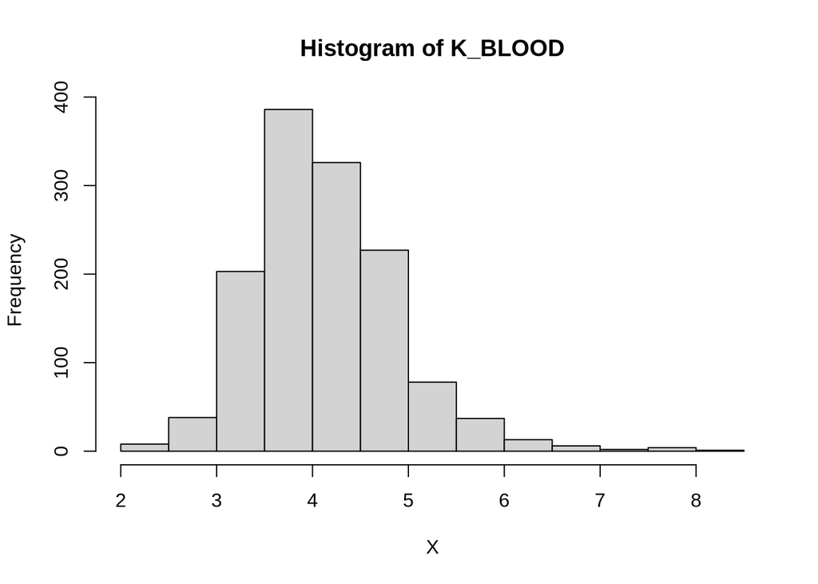

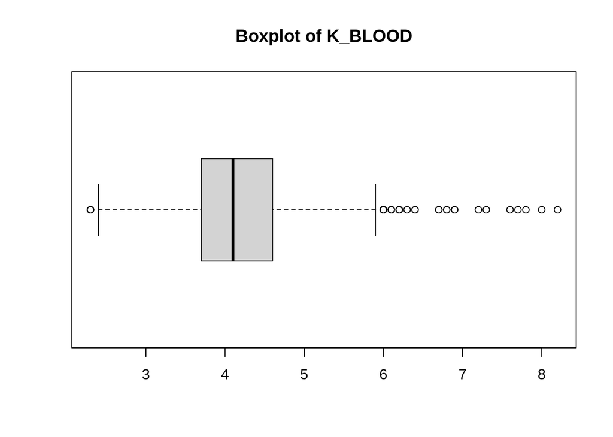

```
## [1] "Extended Summary Statistics"
##    Min. 1st Qu.  Median    Mean 3rd Qu.    Max.    NA's
##   2.300   3.700   4.100   4.191   4.600   8.200     371
## [1] "sd:  0.754076378013344"
## [1] "vc:  0.179909433142994"
## [1] "Q-Q plot "
```

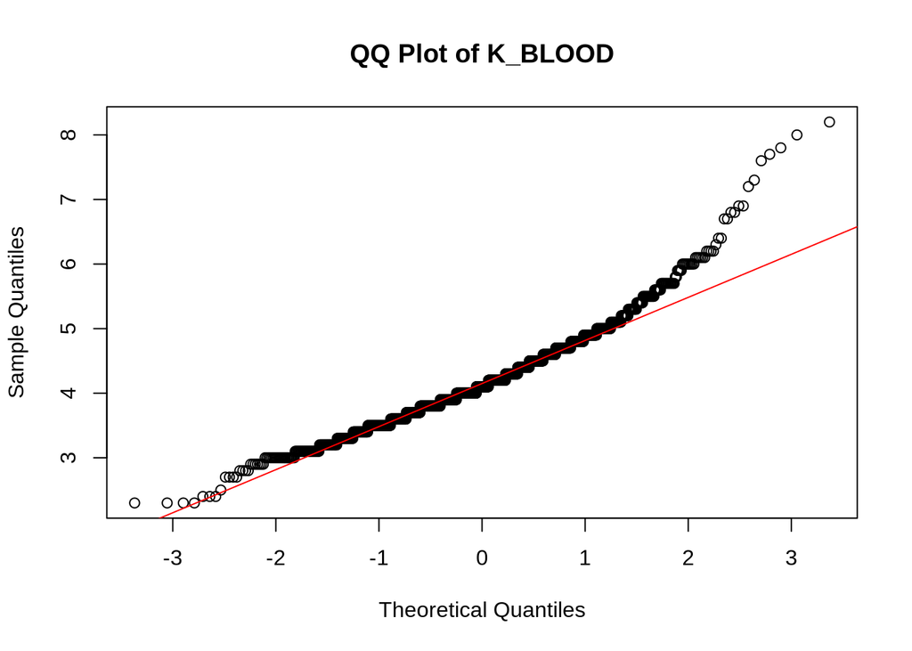

```
##
##  Shapiro-Wilk normality test
##
## data:  X
## W = 0.95587, p-value < 2.2e-16
##
## [1] "variable  12 : NA_BLOOD"
```

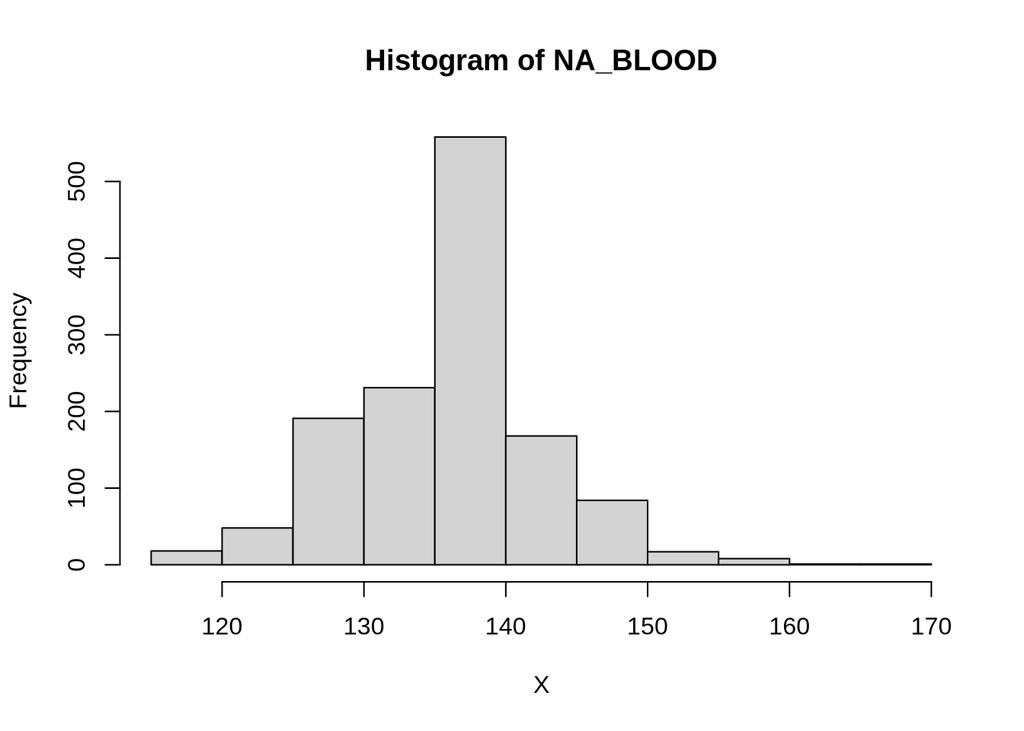

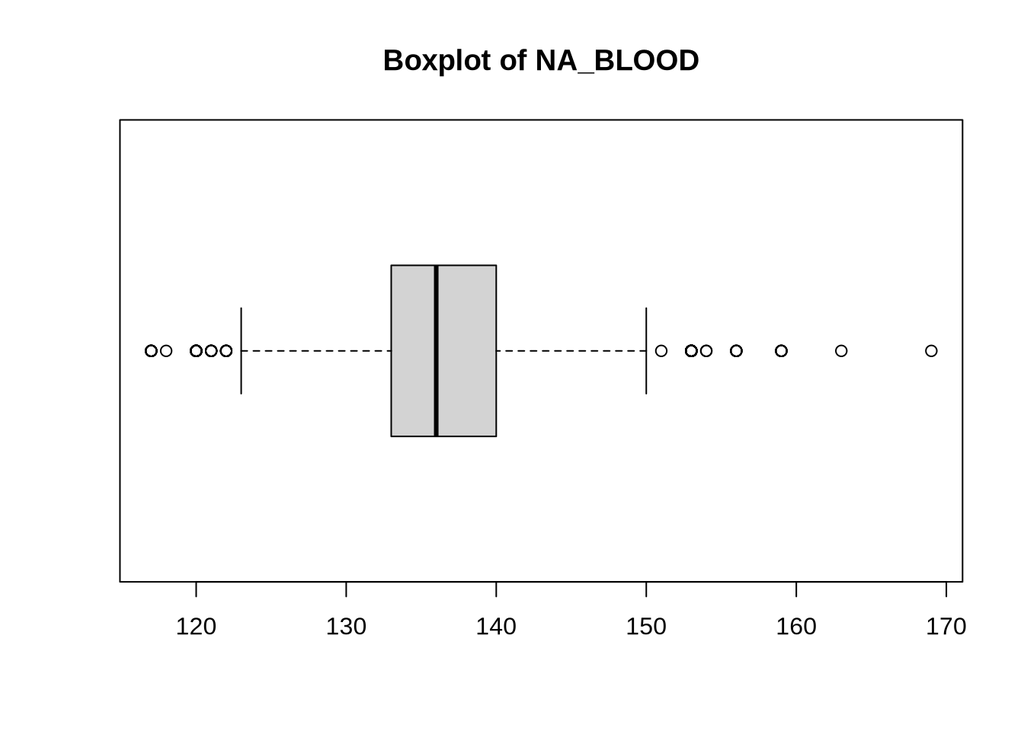

```
## [1] "Extended Summary Statistics"
##    Min. 1st Qu.  Median    Mean 3rd Qu.    Max.    NA's
##   117.0   133.0   136.0   136.6   140.0   169.0     375
## [1] "sd:  6.5121204287015"
## [1] "vc:  0.0476900434865942"
## [1] "Q-Q plot "
```

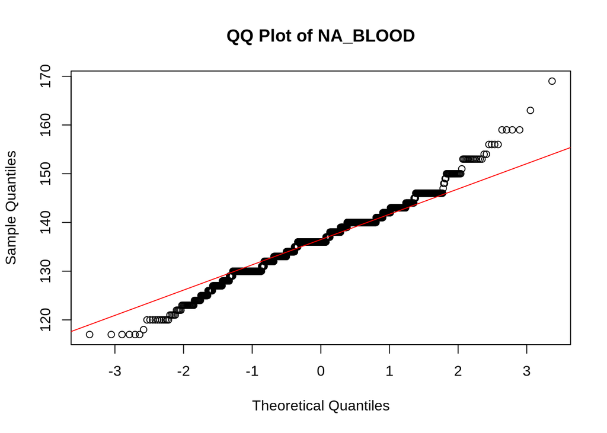

```
##
##  Shapiro-Wilk normality test
##
## data:  X
## W = 0.98009, p-value = 1.485e-12
##
## [1] "variable  13 : L_BLOOD"
```

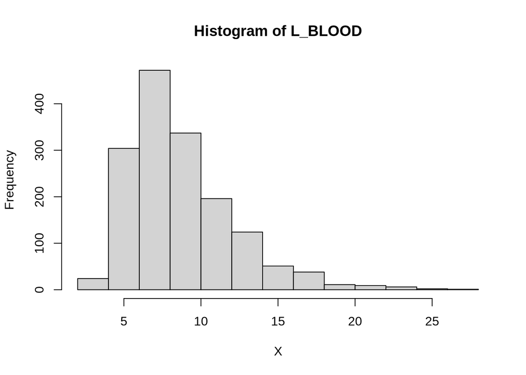

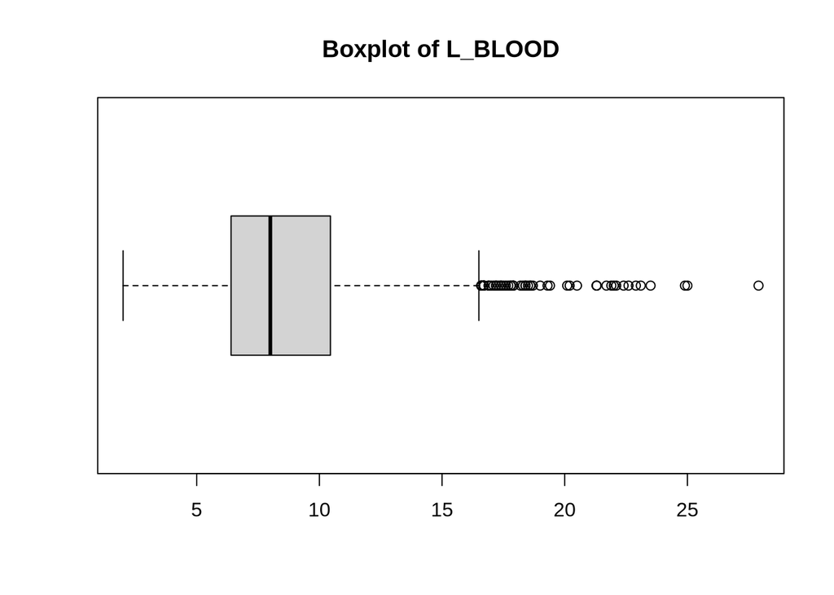

```
## [1] "Extended Summary Statistics"
##    Min. 1st Qu.  Median    Mean 3rd Qu.    Max.    NA's
##   2.000   6.400   8.000   8.783  10.450  27.900     125
## [1] "sd:  3.40055701426411"
## [1] "vc:  0.3871786634415"
## [1] "Q-Q plot "
```

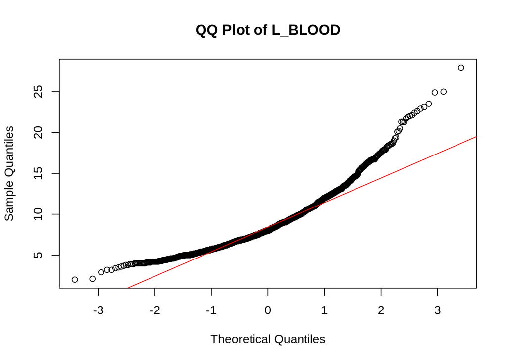

```
##
##  Shapiro-Wilk normality test
##
## data:  X
## W = 0.91225, p-value < 2.2e-16
##
## [1] "variable  14 : ROE"
```

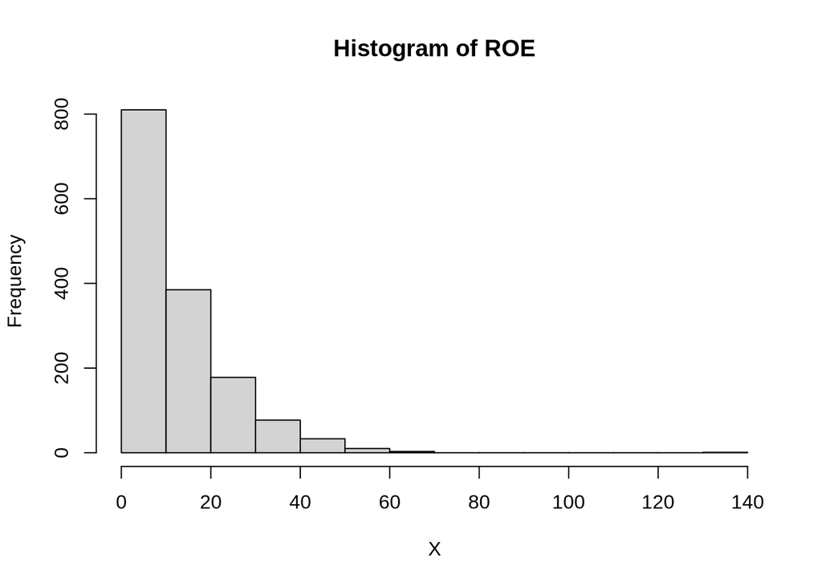